# **ADVERT CONSUMER ANALYSIS**

## **Objective:**

To identify which individuals are most likely to click on website adverts.

## **Success Metric:**

Establish the specific groups of individuals more like to view web adverts on cryptography given the data provided.

## **The context:**

The data was collected from a blog the ran ads to advertise a course. The data contains daily time Spent on site, age of the user, area income, daily internet usage of the user, ad Topic Line, the city, gender,country and the time stamp. The data source can be accessed from http://bit.ly/IPAdvertisingData

## **Reading the data set**

```r
advert <-read.csv('http://bit.ly/IPAdvertisingData')
advert_df <- data.frame(advert)
rmarkdown::paged_table(head(advert_df,n=4))
```

|  | Daily.Time.Spent.on.Site | Age | Area.Income | Daily.Internet.Usage | Ad.Topic.Line | City | Male | Country | Timestamp | Clicked.on.Ad |
| --- | --- | --- | --- | --- | --- | --- | --- | --- | --- | --- |
| 1 | 68.95 | 35 | 61833.90 | 256.09 | Cloned 5thgeneration orchestration | Wrightburgh | 0 | Tunisia | 2016-03-27 00:53:11 | 0 |
| 2 | 80.23 | 31 | 68441.85 | 193.77 | Monitored national standardization | West Jodi | 1 | Nauru | 2016-04-04 01:39:02 | 0 |
| 3 | 69.47 | 26 | 59785.94 | 236.50 | Organic bottom-line service-desk | Davidton | 0 | San Marino | 2016-03-13 20:35:42 | 0 |
| 4 | 74.15 | 29 | 54806.18 | 245.89 | Triple-buffered reciprocal time-frame | West Terrifurt | 1 | Italy | 2016-01-10 02:31:19 | 0 |

```r
#Checking the the last 4 rows of the data set
rmarkdown::paged_table(tail(advert_df,n=4))
```

|  | Daily.Time.Spent.on.Site | Age | Area.Income | Daily.Internet.Usage | Ad.Topic.Line | City | Male | Country | Timestamp | Clicked.on.Ad |
| --- | --- | --- | --- | --- | --- | --- | --- | --- | --- | --- |
| 997 | 51.30 | 45 | 67782.17 | 134.42 | Grass-roots cohesive monitoring | New Darlene | 1 | Bosnia and Herzegovina | 2016-04-22 02:07:01 | 1 |
| 998 | 51.63 | 51 | 42415.72 | 120.37 | Expanded intangible solution | South Jessica | 1 | Mongolia | 2016-02-01 17:24:57 | 1 |
| 999 | 55.55 | 19 | 41920.79 | 187.95 | Proactive bandwidth-monitored policy | West Steven | 0 | Guatemala | 2016-03-24 02:35:54 | 0 |
| 1000 | 45.01 | 26 | 29875.80 | 178.35 | Virtual 5thgeneration emulation | Ronniemouth | 0 | Brazil | 2016-06-03 21:43:21 | 1 |

```r
#Checking the number of rows and columns in the data set
dim(advert_df)
```

```
## [1] 1000   10
```

```r
#The data set has 1000 rows and 10 columns
```

```r
#Checking the data types of the columns
sapply(advert_df, class)
```

```
## Daily.Time.Spent.on.Site                      Age              Area.Income
##                "numeric"                "integer"                "numeric"
##     Daily.Internet.Usage            Ad.Topic.Line                     City
##                "numeric"              "character"              "character"
##                     Male                  Country                Timestamp
##                "integer"              "character"              "character"
##            Clicked.on.Ad
##                "integer"
```

```r
#Checking column names
colnames(advert_df)
```

```
##  [1] "Daily.Time.Spent.on.Site" "Age"
##  [3] "Area.Income"              "Daily.Internet.Usage"
##  [5] "Ad.Topic.Line"            "City"
##  [7] "Male"                     "Country"
##  [9] "Timestamp"                "Clicked.on.Ad"
```

## **Data Cleaning**

**Checking for duplicates**

```r
sum(duplicated(advert_df))
```

```
## [1] 0
```

```r
#The data has no duplicated rows
```

**Checking for missing values**

```r
colSums(is.na(advert_df))
```

```
## Daily.Time.Spent.on.Site                      Age              Area.Income
##                        0                        0                        0
##     Daily.Internet.Usage            Ad.Topic.Line                     City
##                        0                        0                        0
##                     Male                  Country                Timestamp
##                        0                        0                        0
##            Clicked.on.Ad
##                        0
```

```r
#There are no missing values in all columns
```

**Checking for outliers**

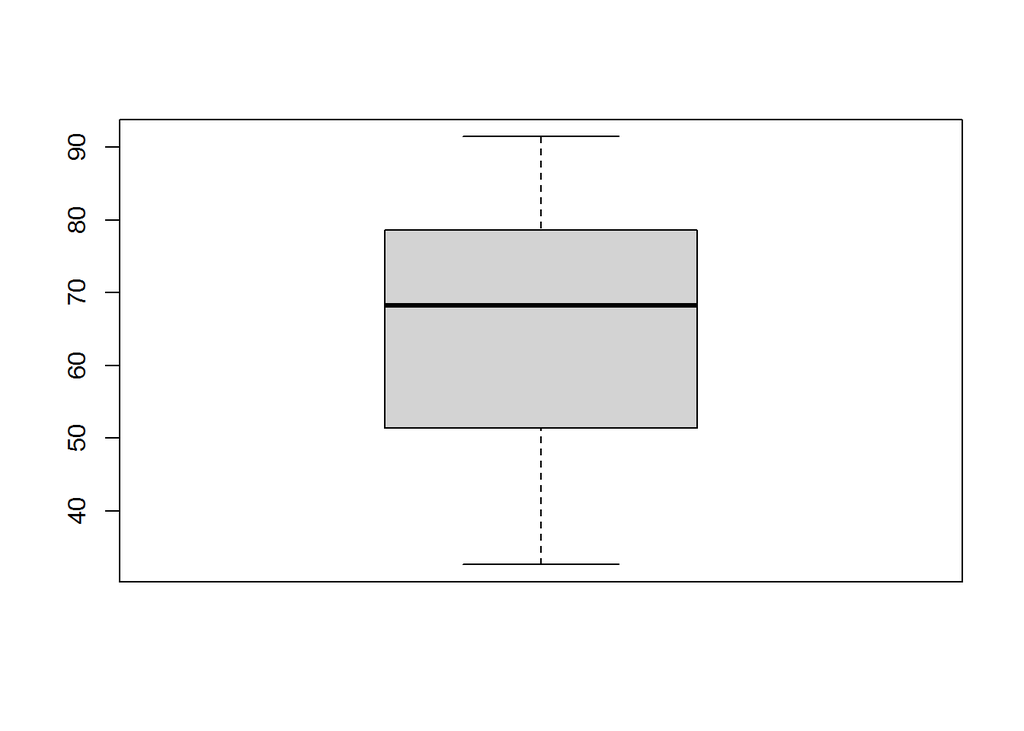

```r
boxplot(advert_df$Daily.Time.Spent.on.Site)
```

```r
#The are no outliers on the 'daily time spent on site' column
```

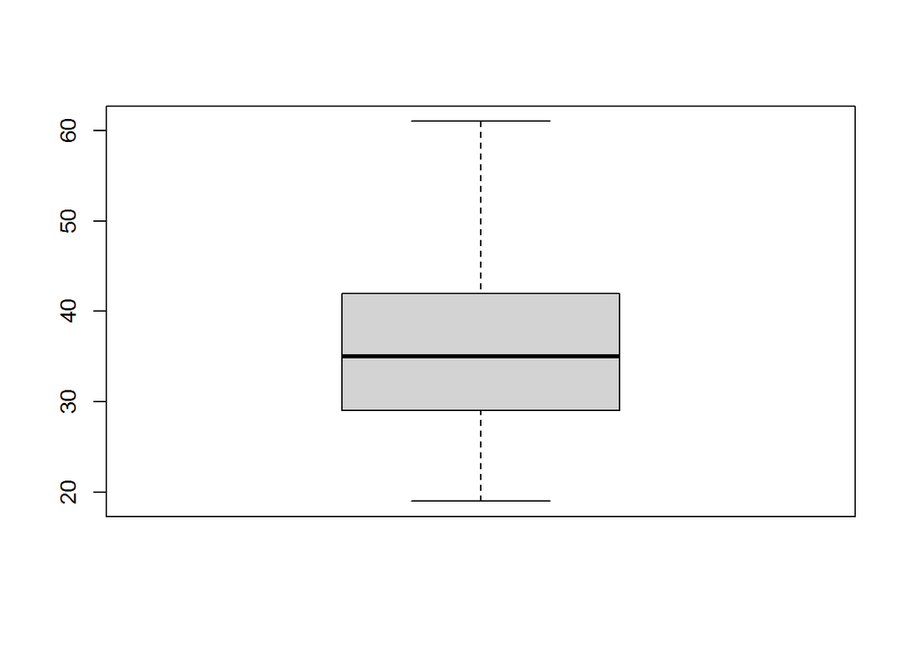

```r
boxplot(advert_df$Age)
```

```r
#The are no outliers on the 'age' column
```

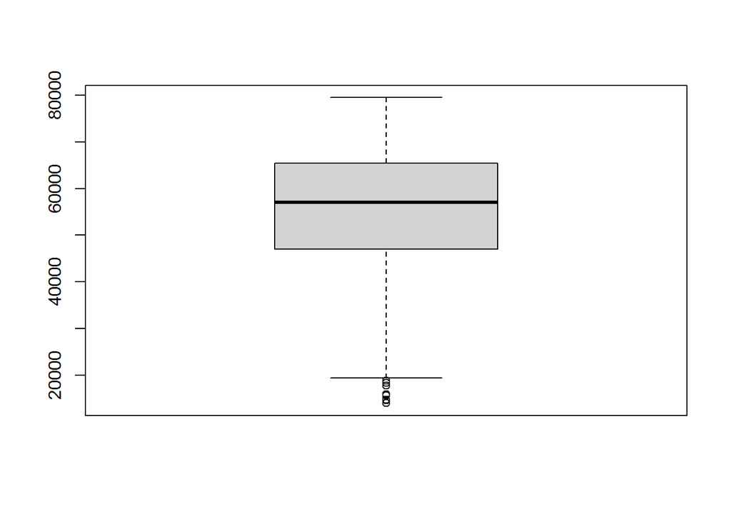

```r
boxplot(advert_df$Area.Income)
```

```r
#The are outliers on the 'area income' column. However, the outliers will not be dropped as they are legitimate  data give the context of the column data.
```

**Correcting column names**

```r
colnames(advert_df)
```

```
##  [1] "Daily.Time.Spent.on.Site" "Age"
##  [3] "Area.Income"              "Daily.Internet.Usage"
##  [5] "Ad.Topic.Line"            "City"
##  [7] "Male"                     "Country"
##  [9] "Timestamp"                "Clicked.on.Ad"
```

```r
#Renaming the 'male' column to 'gender' where 1 represents male and 0 female
colnames(advert_df)[7] <- 'Gender'
#Removing fullstops in the column names
colnames(advert_df)[1] <- 'Daily Time Spent on Site'
colnames(advert_df)[3] <- 'Area Income'
colnames(advert_df)[4] <- 'Daily Internet Usage'
colnames(advert_df)[5] <- 'Ad Topic Line'
colnames(advert_df)[10] <- 'Clicked on Ad'
```

```r
#Checking corrected column names
colnames(advert_df)
```

```
##  [1] "Daily Time Spent on Site" "Age"
##  [3] "Area Income"              "Daily Internet Usage"
##  [5] "Ad Topic Line"            "City"
##  [7] "Gender"                   "Country"
##  [9] "Timestamp"                "Clicked on Ad"
```

**Correcting Column values**

```r
#Changing 0 and 1 values in the gender and clicked on Ad columns in male and female values and yes and no values respectively.It will help in visualizing the outcomes.
advert_df$Gender <- ifelse(advert_df$Gender == 1,'male','female')
advert_df$`Clicked on Ad` <- ifelse(advert_df$`Clicked on Ad`==1,'yes','no')
```

```r
#reading the data to check if the corrections made have reflected
rmarkdown::paged_table(head(advert_df,n=5))
```

|  | Daily Time Spent on Site | Age | Area Income | Daily Internet Usage | Ad Topic Line | City | Gender | Country | Timestamp | Clicked on Ad |
| --- | --- | --- | --- | --- | --- | --- | --- | --- | --- | --- |
| 1 | 68.95 | 35 | 61833.90 | 256.09 | Cloned 5thgeneration orchestration | Wrightburgh | female | Tunisia | 2016-03-27 00:53:11 | no |
| 2 | 80.23 | 31 | 68441.85 | 193.77 | Monitored national standardization | West Jodi | male | Nauru | 2016-04-04 01:39:02 | no |
| 3 | 69.47 | 26 | 59785.94 | 236.50 | Organic bottom-line service-desk | Davidton | female | San Marino | 2016-03-13 20:35:42 | no |
| 4 | 74.15 | 29 | 54806.18 | 245.89 | Triple-buffered reciprocal time-frame | West Terrifurt | male | Italy | 2016-01-10 02:31:19 | no |
| 5 | 68.37 | 35 | 73889.99 | 225.58 | Robust logistical utilization | South Manuel | female | Iceland | 2016-06-03 03:36:18 | no |